# **Sentiment Classification**

### **Dataset**

- Dataset of 50,000 movie reviews from IMDB, labeled by sentiment positive (1) or negative (0)
- Reviews have been preprocessed, and each review is encoded as a sequence of word indexes (integers).
- For convenience, words are indexed by overall frequency in the dataset, so that for instance the integer "3" encodes the 3rd most frequent word in the data. This allows for quick filtering operations such as: "only consider the top 10,000 most common words, but eliminate the top 20 most common words".
- As a convention, "0" does not stand for a specific word, but instead is used to encode any unknown word.

### **Import the data**

```python
from tensorflow.keras.datasets import imdb
# Numerical calculation
import numpy as np
import pandas as pd

# Utilities
from time import time
import itertools
import warnings

# Data Visualization
import matplotlib.pyplot as plt
import scikitplot as skplt
import seaborn as sns
%matplotlib inline
plt.style.use('ggplot')

from keras.preprocessing.sequence import pad_sequences

from keras.models import Sequential
from keras.layers import Dense, Flatten, LSTM, Dropout, Embedding, TimeDistributed, Bidirectional,Dropout, Conv1D, MaxPooling1D
from keras.callbacks import EarlyStopping

# Evaluation metrics
from sklearn.metrics import confusion_matrix, classification_report, roc_curve, auc, accuracy_score, precision_recall_curve
```

```python
#Taking 10000 most frequent words
most_freq = 10000

# Load dataset
(X_train, y_train), (X_test, y_test) = imdb.load_data(num_words=most_freq)
```

```
train_data (25000,)
train_labels (25000,)
____________________________________________________________________________________________________
test_data (25000,)
test_labels (25000,)
____________________________________________________________________________________________________
Minimum value of a word index in train set : 1
Maximum value of a word index in train set : 9999
Minimum value of a word index in test set: 1
Maximum value of a word index in test set: 9999
____________________________________________________________________________________________________
Minimum number of words in reviews of train set : 11
Maximum number of words in reviews of train set : 2494
Minimum number of words in reviews of test set : 7
Maximum number of words in reviews of test set : 2315
```

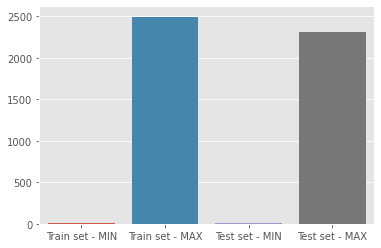

```python
# Taking a look at the data

print('train_data', X_train.shape)
print('train_labels', y_train.shape)
print('_'*100)
print('test_data', X_test.shape)
print('test_labels', y_test.shape)
print('_'*100)
print('Minimum value of a word index in train set :', min([min(review) for review in X_train ]) )
print('Maximum value of a word index in train set :', max([max(review) for review in X_train ]) )
print('Minimum value of a word index in test set:', min([min(review) for review in X_test ]) )
print('Maximum value of a word index in test set:', max([max(review) for review in X_test ]) )
print('_'*100)
len_train = [len(review) for review in X_train]
len_test = [len(review) for review in X_test]
print('Minimum number of words in reviews of train set :', min(len_train))
print('Maximum number of words in reviews of train set :', max(len_train))
print('Minimum number of words in reviews of test set :', min(len_test))
print('Maximum number of words in reviews of test set :', max(len_test))

sns.barplot(x=['Train set - MIN','Train set - MAX','Test set - MIN','Test set - MAX'],
            y=[min(len_train),max(len_train),min(len_test),max(len_test)])
```

**Sentiment Types**

```python
# Checking the distinct sentiments
unique, counts = np.unique(np.concatenate((y_train, y_test)), return_counts= True)
print(unique)
```

```
[0 1]
```

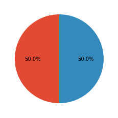

```python
# Visualize the proportion of Positive and Negative reviews in the whole dataset
_ = plt.pie(counts, autopct='%1.1f%%', startangle=90)
```

### **Pad each sentence to be of same length**

```python
#The Maximum Number of word length for each review
reviewlen = 300

#used post padding to keep dummy words, if needed, added at the end, as it is possible to have reviews
#exceed 300 words
X_train = pad_sequences(X_train, maxlen=reviewlen, padding='post')
X_test =  pad_sequences(X_test, maxlen=reviewlen, padding='post')
```

```python
X_train.shape
```

```
(25000, 300)
```

```python
X_test.shape
```

```
(25000, 300)
```

```python
print("Checking words index in any review : :",X_train[1])
#Since this one has a review less than 300 words, zeros are padded at the end to fix at 300 word length
```

```
Checking words index in any review : : [   1  194 1153  194 8255   78  228    5    6 1463 4369 5012  134   26
    4  715    8  118 1634   14  394   20   13  119  954  189  102    5
  207  110 3103   21   14   69  188    8   30   23    7    4  249  126
   93    4  114    9 2300 1523    5  647    4  116    9   35 8163    4
  229    9  340 1322    4  118    9    4  130 4901   19    4 1002    5
   89   29  952   46   37    4  455    9   45   43   38 1543 1905  398
    4 1649   26 6853    5  163   11 3215    2    4 1153    9  194  775
    7 8255    2  349 2637  148  605    2 8003   15  123  125   68    2
 6853   15  349  165 4362   98    5    4  228    9   43    2 1157   15
  299  120    5  120  174   11  220  175  136   50    9 4373  228 8255
    5    2  656  245 2350    5    4 9837  131  152  491   18    2   32
 7464 1212   14    9    6  371   78   22  625   64 1382    9    8  168
  145   23    4 1690   15   16    4 1355    5   28    6   52  154  462
   33   89   78  285   16  145   95    0    0    0    0    0    0    0
    0    0    0    0    0    0    0    0    0    0    0    0    0    0
    0    0    0    0    0    0    0    0    0    0    0    0    0    0
    0    0    0    0    0    0    0    0    0    0    0    0    0    0
    0    0    0    0    0    0    0    0    0    0    0    0    0    0
    0    0    0    0    0    0    0    0    0    0    0    0    0    0
    0    0    0    0    0    0    0    0    0    0    0    0    0    0
    0    0    0    0    0    0    0    0    0    0    0    0    0    0
    0    0    0    0    0    0]
```

```python
print("Checking words index in any review : :",X_train[10])
#Looks like this one has review with atleast 300 words
```

```
Checking words index in any review : : [   6  346  137   11    4 2768  295   36 7740  725    6 3208  273   11
    4 1513   15 1367   35  154    2  103    2  173    7   12   36  515
 3547   94 2547 1722    5 3547   36  203   30  502    8  361   12    8
  989  143    4 1172 3404   10   10  328 1236    9    6   55  221 2989
    5  146  165  179  770   15   50  713   53  108  448   23   12   17
  225   38   76 4397   18  183    8   81   19   12   45 1257    8  135
   15    2  166    4  118    7   45    2   17  466   45    2    4   22
  115  165  764 6075    5 1030    8 2973   73  469  167 2127    2 1568
    6   87  841   18    4   22    4  192   15   91    7   12  304  273
 1004    4 1375 1172 2768    2   15    4   22  764   55 5773    5   14
 4233 7444    4 1375  326    7    4 4760 1786    8  361 1236    8  989
   46    7    4 2768   45   55  776    8   79  496   98   45  400  301
   15    4 1859    9    4  155   15   66    2   84    5   14   22 1534
   15   17    4  167    2   15   75   70  115   66   30  252    7  618
   51    9 2161    4 3130    5   14 1525    8 6584   15    2  165  127
 1921    8   30  179 2532    4   22    9  906   18    6  176    7 1007
 1005    4 1375  114    4  105   26   32   55  221   11   68  205   96
    5    4  192   15    4  274  410  220  304   23   94  205  109    9
   55   73  224  259 3786   15    4   22  528 1645   34    4  130  528
   30  685  345   17    4  277  199  166  281    5 1030    8   30  179
 4442  444    2    9    6  371   87  189   22    5   31    7    4  118
    7    4 2068  545 1178  829]
```

**Analyze how much portion of original data we're trimming off by considering 300 as the maxlen**

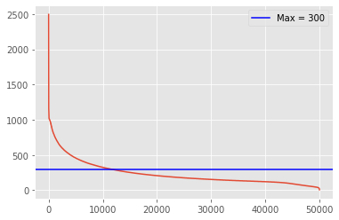

```python
(train_data, _), (test_data, _) = imdb.load_data(num_words=most_freq)
imdb_len = [len(review) for review in np.concatenate((train_data, test_data))]
plt.plot(np.sort(imdb_len)[::-1])
plt.axhline(300, color = 'b', label='Max = 300')
plt.legend()
```

```python
print('Trimming off %.2f%% of data by setting 300 as maxlen'
      % (len([i for i in imdb_len if i > 300]) / len(imdb_len) * 100))
```

```
Trimming off 22.83% of data by setting 300 as maxlen
```

So here we can see that only a little above 1/5 th of the data is truncated

### **Print shape of features & labels**

Number of review, number of words in each review

```python
print ("Number of reviews in Training Set: ", X_train.shape[0])
print ("Number of reviews in Test Set    : ", X_test.shape[0])
```

```
Number of reviews in Training Set:  25000
Number of reviews in Test Set    :  25000
```

```python
print ("Number of words in each review of Training Set: ", X_train.shape[1])
print ("Number of words in each review of Test Set    : ", X_test.shape[1])
```

```
Number of words in each review of Training Set:  300
Number of words in each review of Test Set    :  300
```

```python
# Train Set

review_wordcount_excluding0_train = ([review[review!=0].size for review in X_train ])

print("Number of Reviews in the List: ",len(review_wordcount_excluding0_train))
print('_'*100)
print("Printing a random range of 10 review word count from the entire Train Set of 25000")
for i in range(1000,1010):
    print(i, review_wordcount_excluding0_train[i])
```

```
Number of Reviews in the List:  25000
____________________________________________________________________________________________________
Printing a random range of 10 review word count from the entire Train Set of 25000
1000 298
1001 181
1002 216
1003 152
1004 99
1005 182
1006 135
1007 169
1008 103
1009 109
```

```python
# Test Set

review_wordcount_excluding0_test = ([review[review!=0].size for review in X_test ])

print("Number of Reviews in the List: ",len(review_wordcount_excluding0_test))
print('_'*100)
print("Printing a random range of 10 review word count from the entire Test Set of 25000")
for i in range(10000,10010):
    print(i, review_wordcount_excluding0_test[i])
```

```
Number of Reviews in the List:  25000
____________________________________________________________________________________________________
Printing a random range of 10 review word count from the entire Test Set of 25000
10000 132
10001 188
10002 131
10003 111
10004 206
10005 126
10006 300
10007 95
10008 299
10009 232
```

**Number of labels**

```python
print("Number of labels in Training Set ", np.unique(y_train))
print("Number of labels in Test Set     ", np.unique(y_test))
```

```
Number of labels in Training Set  [0 1]
Number of labels in Test Set      [0 1]
```

### **Print value of any one feature and it's label**

Feature value

```python
print("Feature:", X_train[100])
```

```
Feature: [   1   13  244    6   87  337    7  628 2219    5   28  285   15  240
   93   23  288  549   18 1455  673    4  241  534 3635 8448   20   38
   54   13  258   46   44   14   13 1241 7258   12    5    5   51    9
   14   45    6  762    7    2 1309  328    5  428 2473   15   26 1292
    5 3939 6728    5 1960  279   13   92  124  803   52   21  279   14
    9   43    6  762    7  595   15   16    2   23    4 1071  467    4
  403    7  628 2219    8   97    6  171 3596   99  387   72   97   12
  788   15   13  161  459   44    4 3939 1101  173   21   69    8  401
    2    4  481   88   61 4731  238   28   32   11   32   14    9    6
  545 1332  766    5  203   73   28   43   77  317   11    4    2  953
  270   17    6 3616   13  545  386   25   92 1142  129  278   23   14
  241   46    7  158    0    0    0    0    0    0    0    0    0    0
    0    0    0    0    0    0    0    0    0    0    0    0    0    0
    0    0    0    0    0    0    0    0    0    0    0    0    0    0
    0    0    0    0    0    0    0    0    0    0    0    0    0    0
    0    0    0    0    0    0    0    0    0    0    0    0    0    0
    0    0    0    0    0    0    0    0    0    0    0    0    0    0
    0    0    0    0    0    0    0    0    0    0    0    0    0    0
    0    0    0    0    0    0    0    0    0    0    0    0    0    0
    0    0    0    0    0    0    0    0    0    0    0    0    0    0
    0    0    0    0    0    0    0    0    0    0    0    0    0    0
    0    0    0    0    0    0]
```

Label value

```python
print("Label:", y_train[100])
```

```
Label: 0
```

### **Decode the feature value to get original sentence**

First, retrieve a dictionary that contains mapping of words to their index in the IMDB dataset

```python
word_index_dict = imdb.get_word_index()
```

Now use the dictionary to get the original words from the encodings, for a particular sentence

```python
sentiments = {1: 'Positive', 0: 'Negative'}

def interpret_review(sequence):
    '''Reverse from integers to words using the DICTIONARY
    (given by keras...need to do nothing to create it)'''
    # reverse word index to map integer indexes to their respective words
    id_to_word = dict([(value, key) for (key, value) in imdb.get_word_index().items()])
    #decode the review, mapping integer indices to words
    # indices are off by 3 because 0, 1, and 2 are reserverd indices for "padding",
    # "Start of sequence" and "unknown"
    decoded_review = ' '.join([id_to_word.get(idx-3, '?') for idx in sequence])
    print(decoded_review)
```

Get the sentiment for the above sentence

- positive (1)
- negative (0)

```python
review_1 = np.random.choice(len_train)
interpret_review(X_train[review_1])
print('The sentiment for the above review is:', sentiments.get(y_train[review_1]))

print('_'*100)

review_2 = np.random.choice(len_test)
interpret_review(X_test[review_2])
print('The sentiment for the above review is:', sentiments.get(y_test[review_2]))
```

```
? watching this was like getting a large ? slapped in your face over and over again even when you thought that ? surely can't be coming around again slap there it was i'm not sure what they were thinking this is the sort of pilot i watched and wondered did the actors know they were on a doomed ship …
The sentiment for the above review is: Negative
____________________________________________________________________________________________________
? everything into a large ? of the director's preferred yellow modern love very much ? off the australian countryside john's ? psychological transformation is ? on it and the more the story progresses the more it becomes obvious that nature was an integral part of vision br br in ? the second circle…
The sentiment for the above review is: Positive
```

## **Some Generic methods to plot metric curves**

```python
# Generic method to plot the VALIDATION curves
def plot_validation_curve(history, metrics):
    plt.clf()
    history_dict = history.history
    f, ax = plt.subplots(1, len(metrics), figsize=(16,6))
    for i, metric in enumerate(metrics):
        metric_values = history_dict[metric]
        val_metric_values = history_dict['val_' + metric]
        epochs = range(1, (len(history_dict[metric]) + 1))
        ax[i].plot(epochs, metric_values, 'bo:', label='Training ' + metric)
        ax[i].plot(epochs, val_metric_values, 'go-', label='Validation ' + metric)
        ax[i].set_title('Training and Validation ' + ('Accuracy' if metric=='accuracy' else 'Loss'))
        ax[i].set_xlabel('Epochs')
        ax[i].set_ylabel('Accuracy' if metric=='accuracy' else 'Loss')
        ax[i].legend()
```

```python
# Generic method to plot Precision-Recall curve
def plot_prec_recall_vs_thresh(precisions, recalls, thresholds):
    plt.figure(figsize=(10,5))
    plt.plot(thresholds, precisions[:-1], 'b--', label='precision')
    plt.plot(thresholds, recalls[:-1], 'g--', label = 'recall')
    plt.xlabel('Threshold')
    plt.legend()
```

```python
# Generic method to print the classification report
def classification_summary(y_test, y_pred, y_proba):
    print('\033[1mTesting accuracy:\033[0m %.2f%%' % (accuracy_score(y_test, y_pred) * 100))
    print('_'*80)
    print('\033[1mConfusion matrix:\033[0m\n %s' % (confusion_matrix(y_test, y_pred)))
    print('_'*80)
    print('\033[1mClassification report:\033[0m\n %s' % (classification_report(y_test, y_pred)))
    print('_'*80)
    print('\033[1mPrecision-Recall curve\033[10m')
    precision, recall, thresholds = precision_recall_curve(y_test, y_proba)
    plot_prec_recall_vs_thresh(precision, recall, thresholds)
```

```python
# Generic method to plot ROC curve
def plot_roc(y_test, y_proba):
  y_probas = y_proba.reshape(y_proba.shape[0])
  fpr, tpr, threshold = roc_curve(y_test, y_probas)
  roc_auc = auc(fpr, tpr)
  plt.title('Receiver Operating Characteristic')
  plt.plot(fpr, tpr, 'b', label = 'AUC = %0.2f' % roc_auc)
  plt.legend(loc = 'lower right')
  plt.plot([0, 1], [0, 1],'r--')
  plt.xlim([0, 1])
  plt.ylim([0, 1])
  plt.ylabel('True Positive Rate')
  plt.xlabel('False Positive Rate')
  plt.show()
```

##### **Lets try different Neural Networks to observe their performance before moving on to LSTM**

## **Model 1 - Simple ANN**

```python
embedding_dim = 100
ann = Sequential()
ann.add(Embedding(input_dim = most_freq, output_dim=embedding_dim, input_length=reviewlen))
ann.add(Flatten())
ann.add(Dense(1, activation = 'sigmoid'))
ann.compile(optimizer='adam', loss='binary_crossentropy', metrics=['accuracy'])
ann.summary()
```

```
Model: "sequential_2"
_________________________________________________________________
Layer (type)                 Output Shape              Param #
=================================================================
embedding_2 (Embedding)      (None, 300, 100)          1000000
_________________________________________________________________
flatten_2 (Flatten)          (None, 30000)             0
_________________________________________________________________
dense_4 (Dense)              (None, 1)                 30001
=================================================================
Total params: 1,030,001
Trainable params: 1,030,001
Non-trainable params: 0
_________________________________________________________________
```

```python
#Train the model
epochs = 5
batches = 512
start = time()
model1 = ann.fit(X_train, y_train, epochs = epochs, batch_size=batches, validation_split=0.25)
print('Time spent: %.2f sec' %(time() - start))
```

```
Time spent: 9.44 sec
```

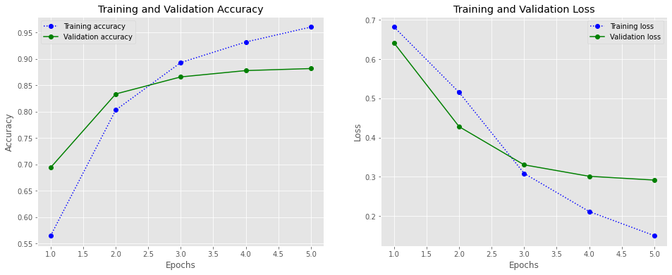

```python
# VALIDATION ACCURACY and LOSS Curve
plot_validation_curve(model1, ['accuracy','loss'])
```

```python
# Find Loss and Accuracy of test set
loss, acc = ann.evaluate(X_test, y_test)
print("Test Loss: %.4f and Accuracy: %.2f%%" % (loss, acc * 100))
```

```
Test Loss: 0.3034 and Accuracy: 87.28%
```

```
Testing accuracy: 87.28%
________________________________________________________________________________
Confusion matrix:
 [[11056  1444]
 [ 1735 10765]]
________________________________________________________________________________
Classification report:
               precision    recall  f1-score   support

           0       0.86      0.88      0.87     12500
           1       0.88      0.86      0.87     12500

    accuracy                           0.87     25000
   macro avg       0.87      0.87      0.87     25000
weighted avg       0.87      0.87      0.87     25000

________________________________________________________________________________
Precision-Recall curve
```

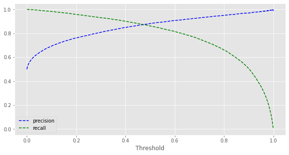

```python
# Analyze classification summary
y_pred = ann.predict_classes(X_test)
y_proba = ann.predict_proba(X_test)
classification_summary(y_test, y_pred, y_proba)
```

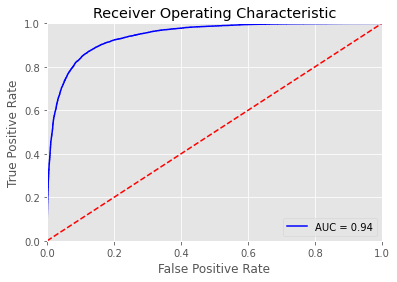

```python
plot_roc(y_test, y_proba)
```

**However, the model is overfitting**

## **Model 2 - Simple CNN**

```python
cnn = Sequential()
cnn.add(Embedding(input_dim = most_freq, output_dim=embedding_dim, input_length=reviewlen))
cnn.add(Dropout(0.2))
cnn.add(Conv1D(filters=32, kernel_size=3, padding='same', activation='relu'))
cnn.add(MaxPooling1D(pool_size=2))
cnn.add(Dropout(0.2))
cnn.add(Flatten())
cnn.add(Dense(250, activation='relu'))
cnn.add(Dense(1, activation='sigmoid'))
cnn.compile(optimizer='adam', loss='binary_crossentropy', metrics=['accuracy'])
cnn.summary()
```

```
Model: "sequential_3"
_________________________________________________________________
Layer (type)                 Output Shape              Param #
=================================================================
embedding_3 (Embedding)      (None, 300, 100)          1000000
_________________________________________________________________
dropout_1 (Dropout)          (None, 300, 100)          0
_________________________________________________________________
conv1d (Conv1D)              (None, 300, 32)           9632
_________________________________________________________________
max_pooling1d (MaxPooling1D) (None, 150, 32)           0
_________________________________________________________________
dropout_2 (Dropout)          (None, 150, 32)           0
_________________________________________________________________
flatten_3 (Flatten)          (None, 4800)              0
_________________________________________________________________
dense_5 (Dense)              (None, 250)               1200250
_________________________________________________________________
dense_6 (Dense)              (None, 1)                 251
=================================================================
Total params: 2,210,133
Trainable params: 2,210,133
Non-trainable params: 0
_________________________________________________________________
```

```python
# Train the model
epochs = 5
batches = 512
start = time()
model2 = cnn.fit(X_train, y_train, epochs=epochs, batch_size=batches, validation_split=0.25)
print('Time spent: %.2f sec' % (time()-start))
```

```
Time spent: 13.48 sec
```

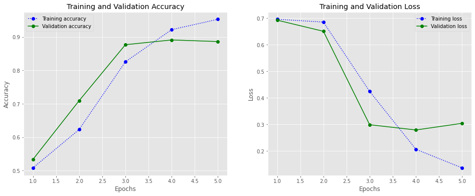

```python
# VALIDATION ACCURACY and LOSS Curve
plot_validation_curve(model2, ['accuracy','loss'])
```

```python
# Find Loss and Accuracy of test set
loss, acc = cnn.evaluate(X_test, y_test)
print("Test Loss: %.4f and Accuracy: %.2f%%" % (loss, acc * 100))
```

```
Test Loss: 0.3276 and Accuracy: 87.52%
```

```
Testing accuracy: 87.52%
________________________________________________________________________________
Confusion matrix:
 [[10687  1813]
 [ 1308 11192]]
________________________________________________________________________________
Classification report:
               precision    recall  f1-score   support

           0       0.89      0.85      0.87     12500
           1       0.86      0.90      0.88     12500

    accuracy                           0.88     25000
   macro avg       0.88      0.88      0.88     25000
weighted avg       0.88      0.88      0.88     25000

________________________________________________________________________________
Precision-Recall curve
```

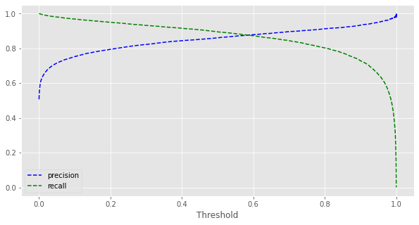

```python
y_pred = cnn.predict_classes(X_test)
y_proba = cnn.predict_proba(X_test)
classification_summary(y_test, y_pred, y_proba)
```

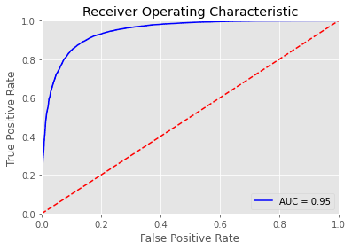

```python
plot_roc(y_test, y_proba)
```

**Similar to ANN model**

## **Model 3 - Simple LSTM**

### **Define model**

- Define a Sequential Model
- Add Embedding layer
  - Embedding layer turns positive integers into dense vectors of fixed size
  - `tensorflow.keras` embedding layer doesn't require us to onehot encode our words, instead we have to give each word a unique integer number as an id. For the imdb dataset we've loaded this has already been done, but if this wasn't the case we could use sklearn LabelEncoder.
  - Size of the vocabulary will be 10000
  - Give dimension of the dense embedding as 100
  - Length of input sequences should be 300
- Add LSTM layer
  - Pass value in `return_sequences` as True
- Add a `TimeDistributed` layer with 100 Dense neurons
- Add Flatten layer
- Add Dense layer

```python
lstm = Sequential()
lstm.add(Embedding(input_dim = most_freq, output_dim=embedding_dim, input_length=reviewlen))
lstm.add(Bidirectional(LSTM(units=100, return_sequences=True, dropout=0.2), merge_mode="concat")) # Default Activation Function is "tanh" is used here
lstm.add(TimeDistributed(Dense(100, activation="relu")))
lstm.add(Flatten())
lstm.add(Dense(50, activation='relu'))
lstm.add(Dropout(0.5))
lstm.add(Dense(1, activation='sigmoid'))
```

### **Compile the model**

```python
lstm.compile(optimizer='adam', loss='binary_crossentropy', metrics=['accuracy'])
```

### **Print model summary**

```python
lstm.summary()
```

```
Model: "sequential_5"
_________________________________________________________________
Layer (type)                 Output Shape              Param #
=================================================================
embedding_5 (Embedding)      (None, 300, 100)          1000000
_________________________________________________________________
bidirectional_2 (Bidirection (None, 300, 200)          160800
_________________________________________________________________
time_distributed_2 (TimeDist (None, 300, 100)          20100
_________________________________________________________________
flatten_5 (Flatten)          (None, 30000)             0
_________________________________________________________________
dense_11 (Dense)             (None, 50)                1500050
_________________________________________________________________
dropout_4 (Dropout)          (None, 50)                0
_________________________________________________________________
dense_12 (Dense)             (None, 1)                 51
=================================================================
Total params: 2,681,001
Trainable params: 2,681,001
Non-trainable params: 0
_________________________________________________________________
```

### **Fit the model**

```python
# Train the model
epochs = 5
batches = 32
earlystop = EarlyStopping(monitor='val_loss', min_delta=0.001, verbose=1, mode='min')
earlycall = [earlystop]
start = time()
model3 = lstm.fit(X_train, y_train, epochs=epochs, batch_size=batches, validation_split=0.25,
                  callbacks = earlycall)
print('Time spent: %.2f sec' % (time()-start))
```

```
Epoch 00002: early stopping
Time spent: 66.13 sec
```

### **Evaluate model**

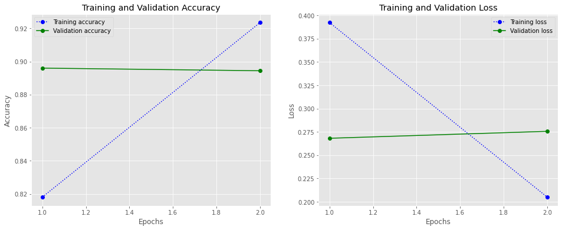

```python
# VALIDATION ACCURACY and LOSS Curve
plot_validation_curve(model3, ['accuracy','loss'])
```

```python
# Find Loss and Accuracy of test set
loss, acc = lstm.evaluate(X_test, y_test)
print("Test Loss: %.4f and Accuracy: %.2f%%" % (loss, acc * 100))
```

```
Test Loss: 0.2900 and Accuracy: 88.33%
```

```
Testing accuracy: 88.33%
________________________________________________________________________________
Confusion matrix:
 [[11120  1380]
 [ 1538 10962]]
________________________________________________________________________________
Classification report:
               precision    recall  f1-score   support

           0       0.88      0.89      0.88     12500
           1       0.89      0.88      0.88     12500

    accuracy                           0.88     25000
   macro avg       0.88      0.88      0.88     25000
weighted avg       0.88      0.88      0.88     25000

________________________________________________________________________________
Precision-Recall curve
```

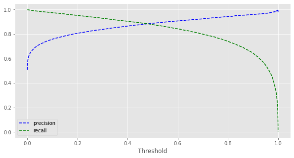

```python
y_pred = lstm.predict_classes(X_test)
y_proba = lstm.predict_proba(X_test)
classification_summary(y_test, y_pred, y_proba)
# skplt.metrics.plot_roc()
# plt.show()
```

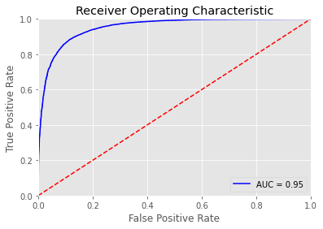

```python
plot_roc(y_test, y_proba)
```

### **Predict on one sample**

```python
review_id = 1001
prediction = lstm.predict_classes(pad_sequences([X_test[review_id]], maxlen=reviewlen))
print('Prediction for Movie Review Number: ',review_id)
print('True Sentiment is ', sentiments.get(y_test[review_id]))
print('Predicted Sentiment is ', sentiments.get(int(prediction[0][0])))
```

```
Prediction for Movie Review Number:  1001
True Sentiment is  Positive
Predicted Sentiment is  Positive
```